# Introduction to Simulation with Variance Estimation

Exercise 4

Bosse Behrens, st.id 12347333

2024W

## Task 1

# part 1

We will draw samples of size 12 from the original sample of size 12. Since we consider two samples with the elements but a different ordering different samples overall, we have $n^n$ possible samples.

```r
data <- c(4.94, 5.06, 4.53, 5.07, 4.99, 5.16, 4.38, 4.43, 4.93, 4.72, 4.92, 4.96)
n <- length(data)
combinations <- n^n
names(combinations) <- c("possible combinations")
print(combinations)
```

```
## possible combinations
##            8.9161e+12
```

# part 2

Calculating mean and median of our provided data.

```r
cat("mean", mean(data), "median", median(data))
```

```
## mean 4.840833 median 4.935
```

# part 3.1-3.3

We create 2000 bootstrap samples by sampling from the original data 2000 times and calculate the mean of each sample as well the mean based on the first 20, 200, 2000 sample means.

```r
set.seed(12347333)
boot_samples <- list()
boot_samples <- lapply(1:2000, function(i) sample(data, 12, replace = TRUE))
boot_means <- sapply(boot_samples, mean)
means_20 <- mean(boot_means[1:20])
means_200 <- mean(boot_means[1:200])
means_2000 <- mean(boot_means[1:2000])
means <- c(means_20, means_200, means_2000)
names <- c("mean of 20 sample means", "mean of 200 sample means", "mean of 2000 sample means")
results <- data.frame(names, means)
print(results)
```

```
##                       names    means
## 1   mean of 20 sample means 4.856292
## 2  mean of 200 sample means 4.841138
## 3 mean of 2000 sample means 4.840721
```

# part 3.4

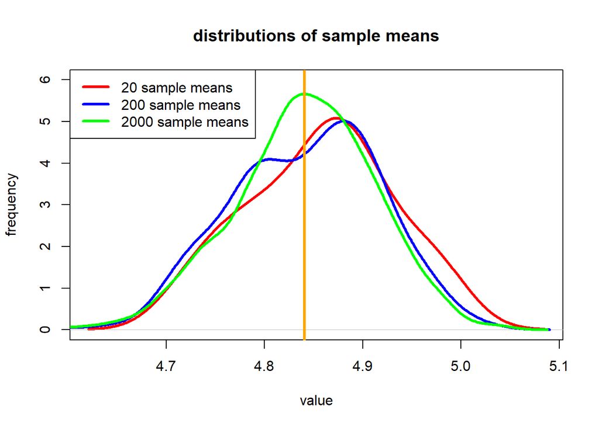

```r
dens_20 <- density(boot_means[1:20])
dens_200 <- density(boot_means[1:200])
dens_2000 <- density(boot_means[1:2000])
plot(dens_20, type = "l", col = "red", ylim = range(c(0, 6)), lwd = 3, ylab = "frequency", xlab ="value", main = "distributions of sample means")
lines(dens_200, col = "blue", lwd = 3)
lines(dens_2000, col = "green", lwd = 3)
abline(v = mean(data), col="orange", lwd = 3) #original sample mean
legend("topleft", legend = c("20 sample means", "200 sample means", "2000 sample means"),
       col = c("red", "blue", "green"), lty = 1, lwd = 3)
```

We can observe that for the first 20 sample means the mode is clearly right of the original sample mean. The distribution for the first 200 sample means looks slightly more centered towards the originals ample mean but still similar to 20. The distribution of the 2000 sample means seems very centered around the original sample mean and the visualization of its distribution is very similar to a normal distribution with the original sample mean as the mean. Therefore it can be concluded that the central limit theorem kicks in since for a larger number of bootstrap samples the distribution of the means follows more a normal distribution.

# part 3.5

```r
q_20 <- quantile(boot_means[1:20], c(0.025,0.975))
q_200 <- quantile(boot_means[1:200],c(0.025,0.975))
q_2000 <- quantile(boot_means[1:2000], c(0.025,0.975))
q_sample <- t.test(data, conf.level = 0.95)

q_names <- c("20 samples", "200 samples", "2000 samples", "\"true\" CI")
q_low <- c(q_20[1], q_200[1], q_2000[1], q_sample$conf.int[1])
q_up <- c(q_20[2], q_200[2], q_2000[2], q_sample$conf.int[2])

results_q <- data.frame(q_names, q_low, q_up)
print(results_q) # results in table
```

```
##        q_names    q_low     q_up
## 1   20 samples 4.730354 4.975083
## 2  200 samples 4.699917 4.970083
## 3 2000 samples 4.694146 4.973333
## 4    "true" CI 4.674344 5.007323
```

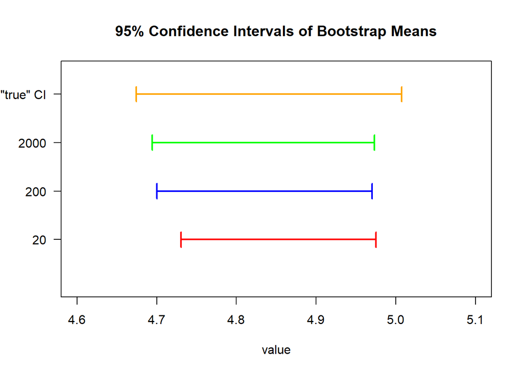

```r
plot(1:4, type = "n", xlim = range(4.6, 5.1), #plotting results
     ylim = c(0, 4.5), yaxt = "n", xaxt = "n", ylab = "", xlab = "value",
     main = "95% Confidence Intervals of Bootstrap Means")
arrows(q_20[1], 1, q_20[2], 1, angle = 90, code = 3, length = 0.1, col = "red", lwd = 2)
arrows(q_200[1], 2, q_200[2], 2, angle = 90, code = 3, length = 0.1, col = "blue", lwd = 2)
arrows(q_2000[1], 3, q_2000[2], 3, angle = 90, code = 3, length = 0.1, col = "green", lwd = 2)
arrows(q_sample$conf.int[1], 4, q_sample$conf.int[2], 4, angle = 90, code = 3, length = 0.1, col = "orange", lwd = 2)

axis(2, at = 1:4, labels = c("20", "200", "2000", "\"true\" CI"), las = 2)
axis(1)
```

We can observe that with fewer samples the confidence interval is also smaller. With an increasing number of bootstrap samples, the confidence intervals for the mean are also getting wider. The “true” confidence interval has the largest range and the with an increasing number of bootstrap samples the confidence intervals are nearing it more and more.

# part 4.1-4.3

We calculate the mean of the medians of the first 20/200/2000 samples similar to the means in part 3.

```r
boot_medians <- sapply(boot_samples, median)
medians_20 <- mean(boot_medians[1:20])
medians_200 <- mean(boot_medians[1:200])
medians_2000 <- mean(boot_medians[1:2000])
medians <- c(medians_20, medians_200, medians_2000)
names_med <- c("mean of 20 sample medians", "mean of 200 sample medians", "mean of 2000 sample medians")
results <- data.frame(names, medians)
print(results) # results in table
```

```
##                       names medians
## 1   mean of 20 sample means 4.93650
## 2  mean of 200 sample means 4.91260
## 3 mean of 2000 sample means 4.91225
```

# part 4.4

Plotting the distribution of the medians.

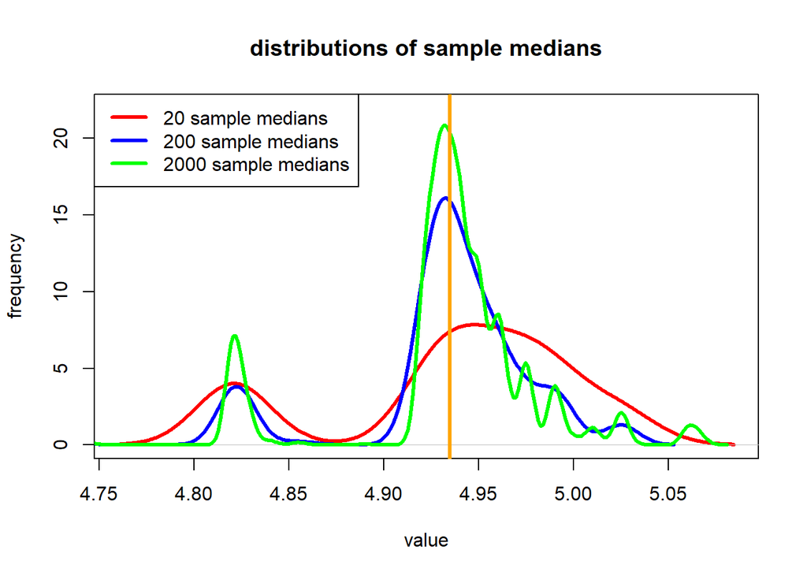

```r
dens_20m <- density(boot_medians[1:20])
dens_200m <- density(boot_medians[1:200])
dens_2000m <- density(boot_medians[1:2000])
plot(dens_20m, type = "l", col = "red", ylim = range(c(0, 22)), lwd = 3, ylab = "frequency", xlab ="value", main = "distributions of sample medians")
lines(dens_200m, col = "blue", lwd = 3)
lines(dens_2000m, col = "green", lwd = 3)
abline(v = median(data), col="orange", lwd = 3)
legend("topleft", legend = c("20 sample medians", "200 sample medians", "2000 sample medians"),
       col = c("red", "blue", "green"), lty = 1, lwd = 3)
```

As we can observe, we can not recognize any similarity to a normal distribution for the distributions of the sample mean. There seem to be multiple local maxima and overall not much likeness to a normal distribution. Therefore we cannot observe the central limit theorem. It might work with an even larger sample size but that is only an assumption. The central limit theorem specifically applies to the sample mean so for other values like the median which also has a discrete range things get more complicated. Due to its sensitivity to outliers the mean also smoothes out way more quickly than a robust indicator like the median.

# part 4.5

```r
q_20m <- quantile(boot_medians[1:20], c(0.025,0.975))
q_200m <- quantile(boot_medians[1:200],c(0.025,0.975))
q_2000m <- quantile(boot_medians[1:2000], c(0.025,0.975))

q_names <- c("20 samples", "200 samples", "2000 samples")
q_low <- c(q_20m[1], q_200m[1], q_2000m[1])
q_up <- c(q_20m[2], q_200m[2], q_2000m[2])

results_q <- data.frame(q_names, q_low, q_up)
print(results_q)
```

```
##        q_names q_low  q_up
## 1   20 samples 4.820 5.025
## 2  200 samples 4.625 5.025
## 3 2000 samples 4.625 5.025
```

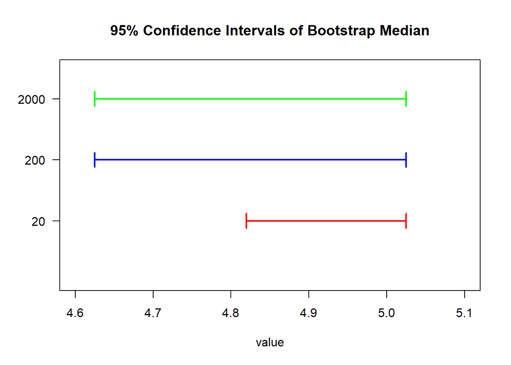

```r
plot(1:3, type = "n", xlim = range(4.6, 5.1),
     ylim = c(0, 3.5), yaxt = "n", xaxt = "n", ylab = "", xlab = "value",
     main = "95% Confidence Intervals of Bootstrap Median")
arrows(q_20m[1], 1, q_20m[2], 1, angle = 90, code = 3, length = 0.1, col = "red", lwd = 2)
arrows(q_200m[1], 2, q_200m[2], 2, angle = 90, code = 3, length = 0.1, col = "blue", lwd = 2)
arrows(q_2000m[1], 3, q_2000m[2], 3, angle = 90, code = 3, length = 0.1, col = "green", lwd = 2)

axis(2, at = 1:3, labels = c("20", "200", "2000"), las = 2)
axis(1)
```

For the first 20 samples the confidence interval seems quite small while the other two are the same and also about double that range. Something like this is to be expected since the median has a range of discrete values.

## Task 2

# part 1

We set the specified seed and create the data x, x.clean and x.cont.

```r
set.seed(1234)
x.clean <- rnorm(1960)
x.cont <- runif(40, 4, 5)
x <- c(x.clean, x.cont)
set.seed(12347333)
```

# part 4.2

We calculate the estimates for median, mean and the trimmed mean for both x and x.clean.

```r
cat("x median", median(x), "x mean", mean(x), "x trimmed mean", mean(x, trim = 0.05))
```

```
## x median 0.0113797 x mean 0.08395508 x trimmed mean 0.03683294
```

```r
cat("x.clean median", median(x.clean), "x.clean mean", mean(x.clean), "x.clean trimmed mean", mean(x.clean, trim = 0.05))
```

```
## x.clean median -0.0172536 x.clean mean -0.005968976 x.clean trimmed mean -0.001462623
```

We implement nonparametric bootstrap by creating 1000 new samples from the original data and applying median, mean and trimmed mean. First we write the function that does just that for some input data. It returns a list with the three vectors containing the medians, means and trimmed means respectively.

```r
boot_func <- function(y){
  n <- length(y)
  boot_median <- replicate(1000, median(sample(y, n, replace = TRUE)))
  boot_mean <- replicate(1000, mean(sample(y, n, replace = TRUE)))
  boot_mean_trim <- replicate(1000, mean(sample(y, n, replace = TRUE), trim = 0.05))
  return(list(boot_median, boot_mean, boot_mean_trim))
}
```

Now we execute the function on x and x.clean and calculate the standard error and 95% confidence interval using the result vectors. Then we put the results in a data frame and show the table.

```r
sd_x <- sapply(boot_func(x), sd)
ci_x_clean <- sapply(boot_func(x), function(s){quantile(s, c(0.025,0.975))})
c1 <- ci_x_clean[1,]
c2 <- ci_x_clean[2,]
estimates <- c(median(x), mean(x), mean(x, trim = 0.05))
results_npb <- data.frame(estimates, sd_x, c1, c2)#
rownames(results_npb) <- c("median", "mean", "trimmed mean")
colnames(results_npb) <- c("estimate", "standard_error", "lower ci", "upper ci")
print("Results for x:")
```

```
## [1] "Results for x:"
```

```r
print(results_npb) # showing results in a table
```

```
##                estimate standard_error     lower ci   upper ci
## median       0.01137970     0.02806653 -0.040206937 0.05872684
## mean         0.08395508     0.02719658  0.031844411 0.13264887
## trimmed mean 0.03683294     0.02409846 -0.007910807 0.08144425
```

```r
sd_x_clean <- sapply(boot_func(x.clean), sd)
ci_x_clean <- sapply(boot_func(x.clean), function(s){quantile(s, c(0.025,0.975))})
c1_clean <- ci_x_clean[1,]
c2_clean <- ci_x_clean[2,]
estimates_clean <- c(median(x.clean), mean(x.clean), mean(x.clean, trim = 0.05))
results_npb_clean <- data.frame(estimates_clean, sd_x_clean, c1_clean, c2_clean)
rownames(results_npb_clean) <- c("median", "mean", "trimmed mean")
colnames(results_npb_clean) <- c("estimate", "standard_error", "lower ci", "upper ci")
print("Results for x.clean:")
```

```
## [1] "Results for x.clean:"
```

```r
print(results_npb_clean) # sholwing results in a table
```

```
##                  estimate standard_error    lower ci   upper ci
## median       -0.017253605     0.02713706 -0.06703859 0.04191743
## mean         -0.005968976     0.02199991 -0.04719300 0.03675698
## trimmed mean -0.001462623     0.02245399 -0.04188423 0.04114877
```

Now we want to visualize the data. To do so we use ggplot2 to plot the confidence intervals, estimates and the estimates $+/-$ the standard error.

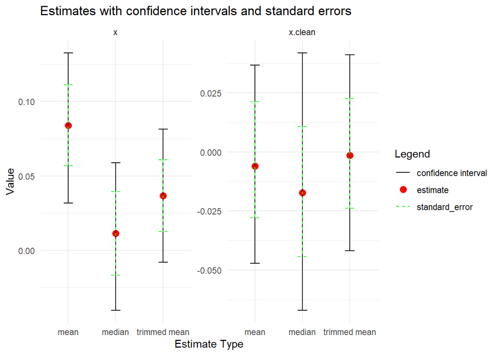

```r
library(ggplot2)
results_npb$estimate_type <- rownames(results_npb) # add column for correct mapping
results_npb_clean$estimate_type <- rownames(results_npb_clean)
results_npb$data_source <- "x"     # add column  to distinguish data
results_npb_clean$data_source <- "x.clean"
results_combined <- rbind(results_npb, results_npb_clean) # combine dataframe

ggplot(results_combined, aes(x = estimate_type)) +
  geom_point(aes(y = estimate, color = "estimate"), size = 3) +
  geom_errorbar(aes(ymin = `lower ci`, ymax = `upper ci`, color = "confidence interval"),
                width = 0.2) +
  geom_errorbar(aes(ymin = estimate - standard_error, ymax = estimate + sd_x, color = "standard_error"),
                width = 0.2, linetype = "dashed") +
  scale_color_manual(values = c("estimate" = "red", "confidence interval" = "black", "standard_error" = "green")) +
  labs(title = "Estimates with confidence intervals and standard errors",
       x = "Estimate Type",
       y = "Value",
       color = "Legend") +
  theme_minimal() +
  facet_wrap(~ data_source, scales = "free")
```

# part 4 We now want to use parametric bootstrap to calculate bias, standard error, the 95 percentile CI and the bias corrected estimate for the mean and the trimmed mean based on x and x.clean. In parametric bootstrapping we have to make an assumption about the underlying distribution of the data. First we make the assumption of standard normal distributed data (as x.clean actually is). This means we use the mean of the data as the location parameter and the standard deviation of the data as the scale parameter for drawing samples. Therefore we write a funciton that draws 1000 samples of the same length as the input data from that distribution. Based on this the aforementioned values for both the mean and the trimmed mean are calculated. The results are returned as a data frame.

```r
boot_param <- function(y){
  n <- length(y)
  sde <- sd(y) # setting assumed parameters
  location <- mean(y)

  means <- numeric(1000)
  trimmed_means <- numeric(1000)
  medians <- numeric(1000)
  for (i in 1:1000) {
    samples <- rnorm(n, location, sde)
    means[i] <- mean(samples)
    trimmed_means[i] <- mean(samples, trim = 0.05)
    medians[i] <- median(samples)
  }
  est <- c(mean(y), mean(y, trim = 0.05), median(y))
  bias <- c(mean(means)-mean(y),
            mean(trimmed_means)-mean(y, trim = 0.05),
            median(medians)-median(y))
  se <- c(sd(means), sd(trimmed_means), sd(medians))
  ci_mean <- quantile(means, c(0.025, 0.975))
  ci_trim <- quantile(trimmed_means, c(0.025, 0.975))
  ci_median <- quantile(medians, c(0.025, 0.975))
  ci_low <- c(ci_mean[1],ci_trim[1], ci_median[1])
  ci_up <- c(ci_mean[2],ci_trim[2], ci_median[2])
  bias_cor <- c(mean(y)-bias[1],
                mean(y, trim = 0.05)-bias[2],
                median(y)-bias[3])

  results <- data.frame(estimate = est,
                        bias = bias,
                        se = se,
                        ci_lower = ci_low,
                        ci_upper = ci_up,
                        bias_corr_estimate = bias_cor)
  rownames(results) <- c("mean", "tr_mean", "median")
  return(results)

}
```

Showing the resulting table.

```r
results_pb <- boot_param(x)
results_pb_clean <- boot_param(x.clean)
print("results for x")
```

```
## [1] "results for x"
```

```r
print(results_pb)
```

```
##           estimate        bias         se   ci_lower  ci_upper
## mean    0.08395508 0.001255616 0.02614410 0.03550537 0.1387855
## tr_mean 0.03683294 0.048344060 0.02630019 0.03552177 0.1383636
## median  0.01137970 0.074598792 0.03242702 0.02333204 0.1494567
##         bias_corr_estimate
## mean            0.08269946
## tr_mean        -0.01151112
## median         -0.06321909
```

```r
print("results for x.clean")
```

```
## [1] "results for x.clean"
```

```r
print(results_pb_clean)
```

```
##             estimate         bias         se    ci_lower   ci_upper
## mean    -0.005968976 -0.001129922 0.02280776 -0.05492990 0.03708279
## tr_mean -0.001462623 -0.005833317 0.02306910 -0.05271906 0.03872808
## median  -0.017253605  0.010370828 0.02791014 -0.06375058 0.04803064
##         bias_corr_estimate
## mean          -0.004839055
## tr_mean        0.004370694
## median        -0.027624433
```

The data is visualized by plotting the confidence intervals as well as the estimates and bias corrected estimates.

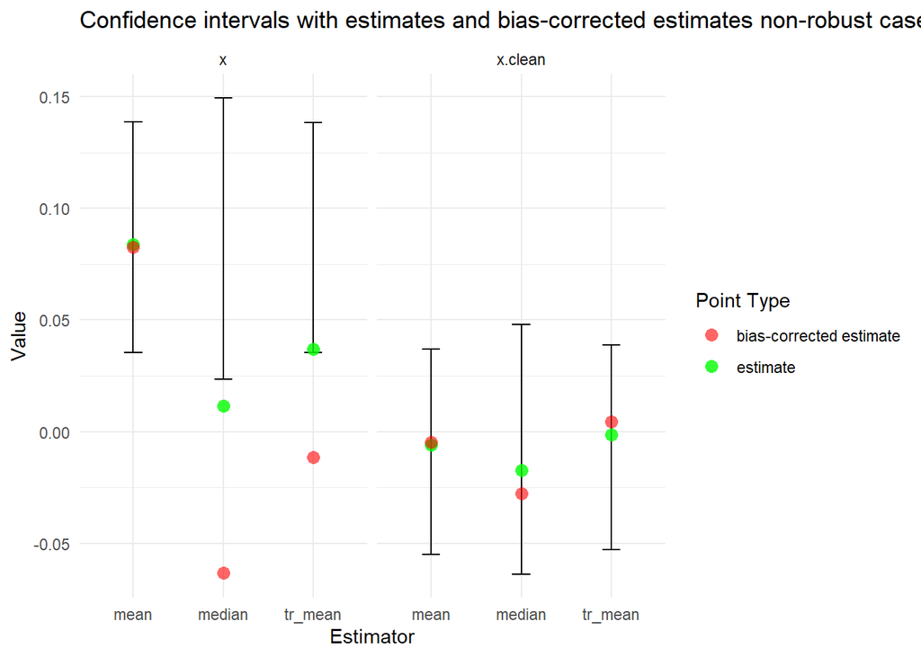

```r
library(ggplot2)
results_pb$Data <- "x" # creating new column to distinguish data
results_pb_clean$Data <- "x.clean"
results_pb$Estimator <- rownames(results_pb) # new column for mapping correctly
results_pb_clean$Estimator <- rownames(results_pb_clean)

combined_results <- rbind(results_pb, results_pb_clean)

ggplot(combined_results, aes(x = Estimator)) +
  geom_errorbar(aes(ymin = ci_lower, ymax = ci_upper), width = 0.2) +
  geom_point(aes(y = estimate, color = "estimate"), size = 3, shape = 16, alpha = 0.8) +
  geom_point(aes(y = bias_corr_estimate, color = "bias-corrected estimate"), size = 3, shape = 16, alpha = 0.6) +
  scale_color_manual(
    name = "Point Type",
    values = c("estimate" = "green", "bias-corrected estimate" = "red"))+
  labs(title = "Confidence intervals with estimates and bias-corrected estimates non-robust case",
       y = "Value",
       x = "Estimator") +
  facet_wrap(~ Data) +
  theme_minimal()
```

As a second implementation we do the same as before but as the assumption of the underlying distribution we use the more robust approach of using the median as the location parameter and as specified the median absolute deviation (MAD) as the scale parameter. The resukts for the mean and the trimmed mean are again returned as a data frame.

```r
boot_param_robust <- function(y){
  n <- length(y)
  sde <- mad(y)
  location <- median(y)

  means <- numeric(1000)
  trimmed_means <- numeric(1000)
  medians <- numeric(1000)
  for (i in 1:1000) {
    samples <- rnorm(n, location, sde)
    means[i] <- mean(samples)
    trimmed_means[i] <- mean(samples, trim = 0.05)
    medians[i] <- median(samples)
  }
  est <- c(mean(y), mean(y, trim = 0.05), median(y))
  bias <- c(mean(means)-mean(y),
            mean(trimmed_means)-mean(y, trim = 0.05),
            median(medians)-median(y))
  se <- c(sd(means), sd(trimmed_means), sd(medians))
  ci_mean <- quantile(means, c(0.025, 0.975))
  ci_trim <- quantile(trimmed_means, c(0.025, 0.975))
  ci_median <- quantile(medians, c(0.025, 0.975))
  ci_low <- c(ci_mean[1],ci_trim[1], ci_median[1])
  ci_up <- c(ci_mean[2],ci_trim[2], ci_median[2])
  bias_cor <- c(mean(y)-bias[1],
                mean(y, trim = 0.05)-bias[2],
                median(y)-bias[3])

  results <- data.frame(estimate = est,
                        bias = bias,
                        se = se,
                        ci_lower = ci_low,
                        ci_upper = ci_up,
                        bias_corr_estimate = bias_cor)
  rownames(results) <- c("mean", "tr_mean", "median")

  return(results)
}
```

Showing the resulting table.

```r
results_pb_robust <- boot_param_robust(x)
results_pb_robust_clean <- boot_param_robust(x.clean)
print(results_pb_robust)
```

```
##           estimate          bias         se    ci_lower   ci_upper
## mean    0.08395508 -0.0733768850 0.02277133 -0.03349527 0.05294980
## tr_mean 0.03683294 -0.0262279383 0.02308336 -0.03496622 0.05350826
## median  0.01137970  0.0000606986 0.02781481 -0.04347866 0.06704980
##         bias_corr_estimate
## mean            0.15733196
## tr_mean         0.06306088
## median          0.01131900
```